# Proyecto 1

## Optimización. Checkpoint 1

Integrantes del Equipo:

- Victor Daniel Yeme
- Santiago Vazquez
- David Lara Medina

Lectura de Dataset (Tech Giants Market Data)

CONTEXTO

El archivo csv es una recopilación del rendimiento de las acciones de siete grandes compañías tecnológicas en las fechas desde el 2 de enero de 2020 hasta el 28 de diciembre del 2023. Las compañías son Google (GOOGL), Meta (META), Microsoft (MSFT), Apple (AAPL), Tesla (TSLA), Amazon (AMZN) y Oracle (ORCL). El dataset se extrajo de la librería yfinance de Python.

```python
import pandas as pd

# Cargar el archivo CSV en un DataFrame
df = pd.read_csv("Tech Giants Stock Market Data (Processed).csv")

# Mostrar las primeras 10 filas
df.head(10)
```

|  | Unnamed: 0 | Date | Open | High | Low | Close | Adj Close | Volume | Ticker | pct_change | cumulative return | moving_avg_7D | moving_avg_30D |
| --- | --- | --- | --- | --- | --- | --- | --- | --- | --- | --- | --- | --- | --- |
| 0 | 6036 | 2020-01-02 | 206.750000 | 209.789993 | 206.270004 | 209.779999 | 208.981705 | 12077100 | META | NaN | 1.000000 | NaN | NaN |
| 1 | 0 | 2020-01-02 | 74.059998 | 75.150002 | 73.797501 | 75.087502 | 72.796013 | 135480400 | AAPL | NaN | 1.000000 | NaN | NaN |
| 2 | 3018 | 2020-01-02 | 93.750000 | 94.900497 | 93.207497 | 94.900497 | 94.900497 | 80580000 | AMZN | NaN | 1.000000 | NaN | NaN |
| 3 | 2012 | 2020-01-02 | 67.420502 | 68.433998 | 67.324501 | 68.433998 | 68.186821 | 27278000 | GOOGL | NaN | 1.000000 | NaN | NaN |
| 4 | 1006 | 2020-01-02 | 158.779999 | 160.729996 | 158.330002 | 160.619995 | 153.630707 | 22622100 | MSFT | NaN | 1.000000 | NaN | NaN |
| 5 | 5030 | 2020-01-02 | 53.270000 | 53.959999 | 53.230000 | 53.950001 | 49.821018 | 13899600 | ORCL | NaN | 1.000000 | NaN | NaN |
| 6 | 4024 | 2020-01-02 | 28.299999 | 28.713333 | 28.114000 | 28.684000 | 28.684000 | 142981500 | TSLA | NaN | 1.000000 | NaN | NaN |
| 7 | 6037 | 2020-01-03 | 207.210007 | 210.399994 | 206.949997 | 208.669998 | 207.875931 | 11188400 | META | -0.529126 | 0.994709 | NaN | NaN |
| 8 | 1 | 2020-01-03 | 74.287498 | 75.144997 | 74.125000 | 74.357498 | 72.088310 | 146322800 | AAPL | -0.972204 | 0.990278 | NaN | NaN |
| 9 | 3019 | 2020-01-03 | 93.224998 | 94.309998 | 93.224998 | 93.748497 | 93.748497 | 75288000 | AMZN | -1.213903 | 0.987861 | NaN | NaN |

```python
# Mostrar información sobre el DataFrame
df.info()
```

```
<class 'pandas.core.frame.DataFrame'>
RangeIndex: 7042 entries, 0 to 7041
Data columns (total 13 columns):
 #   Column             Non-Null Count  Dtype
---  ------             --------------  -----
 0   Unnamed: 0         7042 non-null   int64
 1   Date               7042 non-null   object
 2   Open               7042 non-null   float64
 3   High               7042 non-null   float64
 4   Low                7042 non-null   float64
 5   Close              7042 non-null   float64
 6   Adj Close          7042 non-null   float64
 7   Volume             7042 non-null   int64
 8   Ticker             7042 non-null   object
 9   pct_change         7035 non-null   float64
 10  cumulative return  7042 non-null   float64
 11  moving_avg_7D      7000 non-null   float64
 12  moving_avg_30D     6839 non-null   float64
dtypes: float64(9), int64(2), object(2)
memory usage: 715.3+ KB
```

## Descripción de las Variable

### Date (Fecha / Día de negociación)

-Descripción: Corresponde al día en donde se obtuvieron los datos del precio de los stocks.

-Tipo de Dato: Fecha (cadena de texto)

### Open (Precio de Apertura)

-Descripción: Precio de apertura del stock en ese día.

-Tipo de Dato: Numerico continuo

### High (Máximo)

-Descripción: Precio máximo del stock en ese día.

-Tipo de Dato: Numerico continuo

### Low (Minimos)

-Tipo de Dato: Numerico continuo

### Close (Precio de Cierre)

-Tipo de Dato: Numerico continuo

### Adj.Close (Precio de Cierre Ajustado)

-Descripción: Indica el precio de cierre ajustado al modificar el precio de cierre de una acción para reflejar el valor de esa acción despues de considerar cualquier acción corporativa.

Las acciones corporativas consideran: Las divisiones de acciones,los dividendos y las ofertas de derechos.

-Tipo de Dato: Numerico continuo

-Consideraciones: Se utiliza para conocer los rendimientos historicos, al analizar rendimientos pasados.

### Volume (Volumen)

-Descripción: Es la cantidad de un activo, se refiere al al número de acciones negociadas entre su apertura y cierre diario.

-Tipo de Dato: Numerico Entero

-Consideraciones: Los valores con mayor volumen diario nos indican que la acción es más liquida y activa en los movimientos del mercado.

### Ticker (Símbolo de Cotización)

-Descripción: Nos proporciona información actual para cada acción.

-Tipo de Dato: Cadena de texto

```python
# Mostrar estadísticas descriptivas del DataFrame
df.describe()
```

|  | Unnamed: 0 | Open | High | Low | Close | Adj Close | Volume | pct_change | cumulative return | moving_avg_7D | moving_avg_30D |
| --- | --- | --- | --- | --- | --- | --- | --- | --- | --- | --- | --- |
| count | 7042.00000 | 7042.000000 | 7042.000000 | 7042.000000 | 7042.000000 | 7042.000000 | 7.042000e+03 | 7035.000000 | 7042.000000 | 7000.000000 | 6839.000000 |
| mean | 3520.50000 | 169.401297 | 171.824171 | 166.995613 | 169.466388 | 167.647276 | 5.835253e+07 | 0.125926 | 2.354144 | 169.509895 | 169.690880 |
| std | 2032.99463 | 83.471635 | 84.621488 | 82.224964 | 83.443449 | 83.047480 | 5.966446e+07 | 2.677589 | 2.342510 | 83.157992 | 82.210013 |
| min | 0.00000 | 24.980000 | 26.990667 | 23.367332 | 24.081333 | 24.081333 | 2.168200e+06 | -26.390095 | 0.423825 | 28.866191 | 36.660111 |
| 25% | 1760.25000 | 102.761625 | 104.427000 | 101.392500 | 102.993998 | 102.510376 | 2.139710e+07 | -1.096783 | 1.275847 | 103.094053 | 104.651333 |
| 50% | 3520.50000 | 149.962746 | 151.986671 | 147.831665 | 149.993996 | 148.833290 | 3.891945e+07 | 0.112876 | 1.623686 | 150.170714 | 151.076266 |
| 75% | 5280.75000 | 231.162498 | 234.957504 | 226.912502 | 231.662502 | 228.619858 | 7.661242e+07 | 1.350891 | 2.000734 | 231.574286 | 234.059001 |
| max | 7041.00000 | 411.470001 | 414.496674 | 405.666656 | 409.970001 | 409.970001 | 9.140820e+08 | 23.282400 | 14.292637 | 396.351907 | 374.081335 |

## Detección de valores faltantes y outliers

```python
# Se tienen 3 columnas con información faltante o Nula:
# pct_change (7) , moving_avg_7D (42) , moving_avg_30D (203)

# Contar valores nulos en cada columna
df.isnull().sum()
```

```
Unnamed: 0             0
Date                   0
Open                   0
High                   0
Low                    0
Close                  0
Adj Close              0
Volume                 0
Ticker                 0
pct_change             7
cumulative return      0
moving_avg_7D         42
moving_avg_30D       203
dtype: int64
```

```python
# Filtramos el DataFrame para eliminar filas que contengan valores 0 en las columnas 'pct_change', 'moving_avg_7D' y 'moving_avg_30D'.
# Usamos .loc[] para seleccionar solo las filas que cumplen con la condición.
# axis=1 indica que la evaluación se debe hacer por fila.
# All se utiliza para verificar si todas las condiciones en la fila son verdaderas, podría usarse any que sería para indicar que al menos una condición es verdadera

AccionesTecnologicas_cleaned = df.loc[
    (df[['pct_change', 'moving_avg_7D', 'moving_avg_30D']] != 0).all(axis=1)
]

# axis=1 indica que la evaluación se debe hacer por fila. Y el all, para evaluar que todas las condiciones se cumplanm
(df[['pct_change', 'moving_avg_7D', 'moving_avg_30D']] != 0).all(axis=1)
```

```
0       True
1       True
2       True
3       True
4       True
        ...
7037    True
7038    True
7039    True
7040    True
7041    True
Length: 7042, dtype: bool
```

```python
# Reemplazar los valores de 0 con el promedio en pct_change
# Visualizar el promedio
pct_change_promedio = AccionesTecnologicas_cleaned['pct_change'].mean()
pct_change_promedio

# reemplazar los indices de pct_change que tienen valor 0 por el promedio de la columna
AccionesTecnologicas_cleaned.loc[AccionesTecnologicas_cleaned['pct_change'] == 0, 'pct_change'] = pct_change_promedio
```

```python
# Reemplazar los valores de 0 con el promedio en moving_avg_7D
# Visualizar el promedio
moving_avg_7D_promedio = AccionesTecnologicas_cleaned['moving_avg_7D'].mean()
moving_avg_7D_promedio

# reemplazar los indices de moving_avg_7D que tienen valor 0 por el promedio de la columna
AccionesTecnologicas_cleaned.loc[AccionesTecnologicas_cleaned['moving_avg_7D'] == 0, 'pct_change'] = moving_avg_7D_promedio
```

```python
# Reemplazar los valores de 0 con el promedio en moving_avg_30D
# Visualizar el promedio
moving_avg_30D_promedio = AccionesTecnologicas_cleaned['moving_avg_30D'].mean()
moving_avg_30D_promedio

# reemplazar los indices de moving_avg_30D que tienen valor 0 por el promedio de la columna
AccionesTecnologicas_cleaned.loc[AccionesTecnologicas_cleaned['moving_avg_30D'] == 0, 'pct_change'] = moving_avg_30D_promedio
```

```python
# Visualizar los indices de SkinThickness que tienen valor 0
AccionesTecnologicas_cleaned.loc[AccionesTecnologicas_cleaned['moving_avg_30D'] == 0, 'moving_avg_30D'].head(20)
```

```
Series([], Name: moving_avg_30D, dtype: float64)
```

## Estadística Descriptiva

```python
import numpy as np

# Calcular la media y mediana del precio ajustado
media_adj_close = np.mean(df['Adj Close'])
mediana_adj_close = np.median(df['Adj Close'])

print(f"Media de Precio Ajustado: {media_adj_close}")
print(f"Mediana de Precio Ajustado: {mediana_adj_close}")
```

```
Media de Precio Ajustado: 167.64727587349134
Mediana de Precio Ajustado: 148.83329010009766
```

```python
# Calcular la desviación estándar del precio ajustado
std_adj_close = np.std(df['Adj Close'])
print(f"Desviación Estándar del Precio Ajustado: {std_adj_close}")
```

```
Desviación Estándar del Precio Ajustado: 83.04158361860573
```

```python
# Calcular la media  del cambio porcentual (Tasa de rendimiento)
media_pct_change = np.mean(df['pct_change'])

print(f"Media de Tasa de rendimiento: {media_pct_change}")
```

```
Media de Tasa de rendimiento: 0.1259262535131043
```

```python
# Calcular la desviación estándar de la Tasa de Rendimiento
std_pct_change = np.std(df['pct_change'])
print(f"Desviación Estándar de la Tasa de Rendimiento: {std_pct_change}")
```

```
Desviación Estándar de la Tasa de Rendimiento: 2.677398747376029
```

## Visualizaciones Básicas

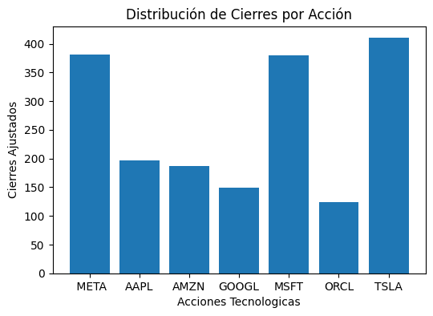

```python
# Crear el gráfico de barras
import matplotlib.pyplot as plt
plt.figure(figsize=(6,4))
plt.bar(AccionesTecnologicas_cleaned['Ticker'], AccionesTecnologicas_cleaned['Adj Close'])
plt.xlabel('Acciones Tecnologicas')
plt.ylabel('Cierres Ajustados')
plt.title('Distribución de Cierres por Acción')
plt.show()
```

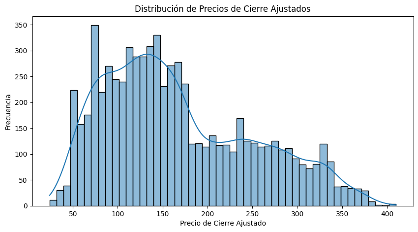

```python
import seaborn as sns

# Histograma de precios de cierre ajustados
plt.figure(figsize=(10, 5))
sns.histplot(AccionesTecnologicas_cleaned['Adj Close'], bins=50, kde=True)
plt.title("Distribución de Precios de Cierre Ajustados")
plt.xlabel("Precio de Cierre Ajustado")
plt.ylabel("Frecuencia")
plt.show()
```

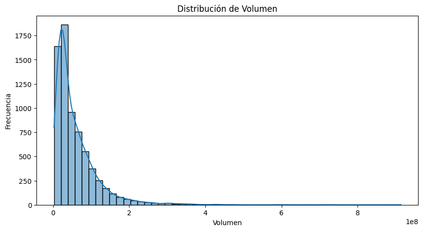

```python
# Histograma de Cantidad de Volumen
plt.figure(figsize=(10, 5))
sns.histplot(AccionesTecnologicas_cleaned['Volume'], bins=50, kde=True)
plt.title("Distribución de Volumen")
plt.xlabel("Volumen")
plt.ylabel("Frecuencia")
plt.show()
```

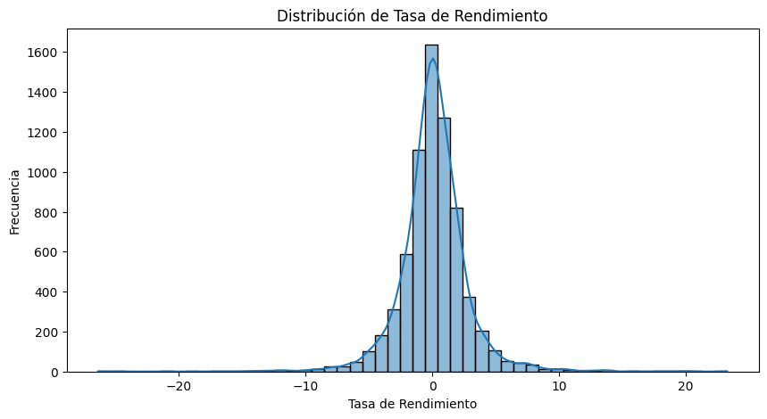

```python
# Histograma de Tasa de rendimiento
plt.figure(figsize=(10, 5))
sns.histplot(AccionesTecnologicas_cleaned['pct_change'], bins=50, kde=True)
plt.title("Distribución de Tasa de Rendimiento")
plt.xlabel("Tasa de Rendimiento")
plt.ylabel("Frecuencia")
plt.show()
```

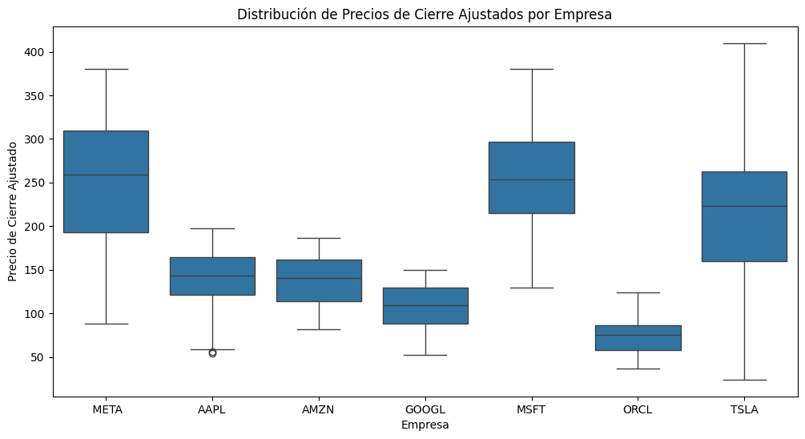

```python
# Boxplot por empresa
plt.figure(figsize=(12, 6))
sns.boxplot(x="Ticker", y="Adj Close", data=AccionesTecnologicas_cleaned)
plt.title("Distribución de Precios de Cierre Ajustados por Empresa")
plt.xlabel("Empresa")
plt.ylabel("Precio de Cierre Ajustado")
plt.show()
```

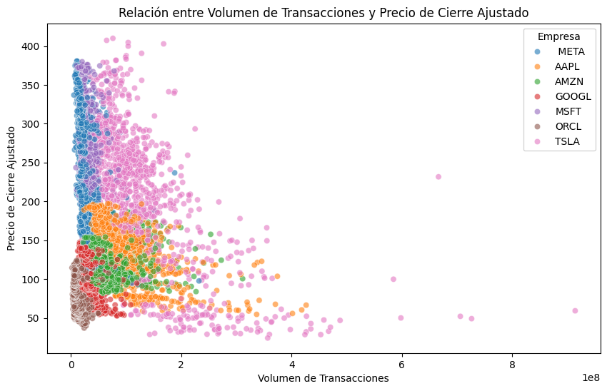

```python
# Gráfico de dispersión entre volumen y precio de cierre ajustado
plt.figure(figsize=(10, 6))
sns.scatterplot(x="Volume", y="Adj Close", hue="Ticker", data=AccionesTecnologicas_cleaned, alpha=0.6)
plt.title("Relación entre Volumen de Transacciones y Precio de Cierre Ajustado")
plt.xlabel("Volumen de Transacciones")
plt.ylabel("Precio de Cierre Ajustado")
plt.legend(title="Empresa")
plt.show()
```

## Identificación de Posibles Relaciones

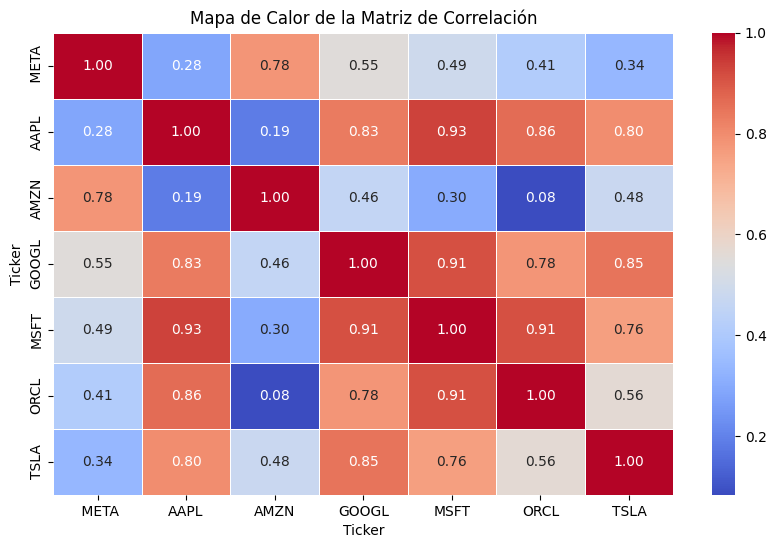

```python
import seaborn as sns

# Al tener un dataframe con un formato revuelto, utilizamos pivot para reorganizarlo antes de calcular la correlación de los activos
# de acuerdo a su valor de cierre

df_pivot = df.pivot(index='Date', columns='Ticker', values='Close')

# Calcular la correlación entre los precios de cierre
correlacion = df_pivot.corr()


# Crear el mapa de calor
plt.figure(figsize=(10,6))
sns.heatmap(correlacion, annot=True, cmap='coolwarm', fmt='.2f', linewidths=0.5)
plt.title('Mapa de Calor de la Matriz de Correlación')
plt.show()
```

Con esta correlación podemos construir un portafolio de inversión destinado a empresas tecnologicas que permitan una mejor diversificación al presentar una menor correlación, lo que minimiza nuestro riesgo y al mismo tiempo podemos maximar las ganancias o rentabilidad con una buena optimización en la elección de activos y su respectivo peso.

https://www.investopedia.com/ask/answers/12/what-is-a-stock-ticker.asp